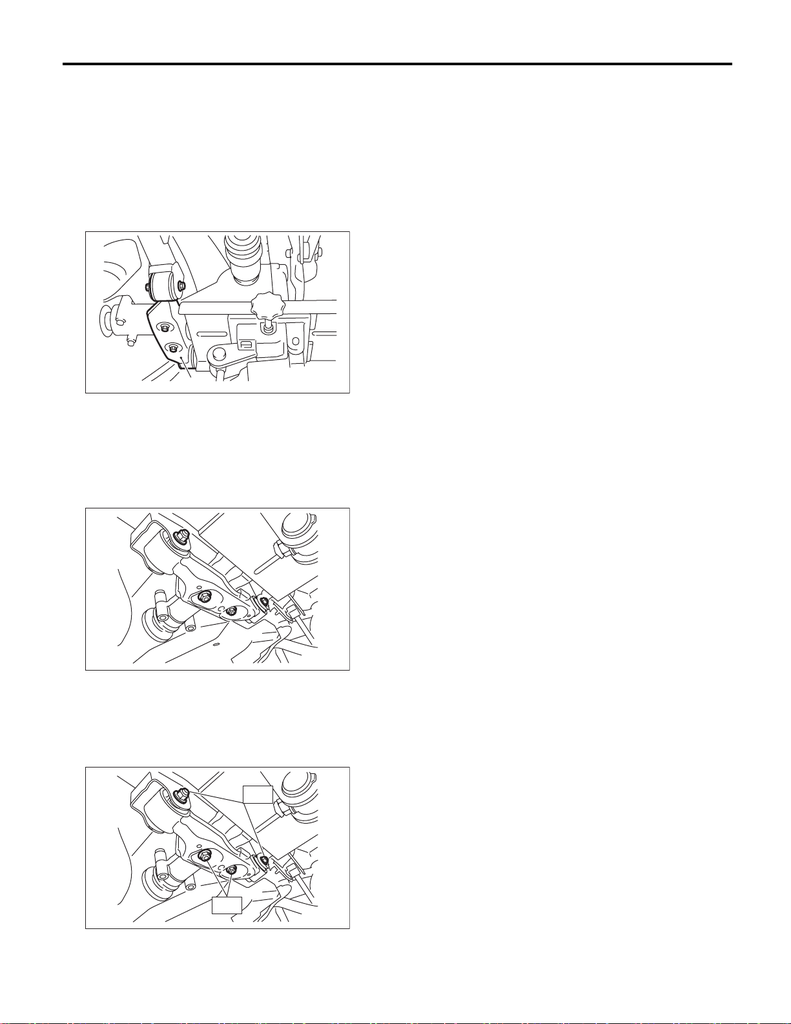

Rear Differential Front Member

DIFFERENTIALS

7. Rear Differential Front Mem-

ber

A: REMOVAL

1) Disconnect the ground cable from battery.

2) Lift up the vehicle.

3) Support the rear differential using transmission

jack, and then remove the rear differential front

member.

B: INSTALLATION

1) Install the rear differential front member, and

temporarily attach and tighten a new self-locking

nut.

2) Remove the transmission jack.

3) Tighten the self-locking nut.

Tightening torque:

T1: 50 N·m (5.1 kgf-m, 36.9 ft-lb)

T2: 110 N·m (11.2 kgf-m, 81.1 ft-lb)

C: INSPECTION

1) Check the rear differential front member for

damage, bend and corrosion.

If damage, bend or corrosion is excessive, replace

the rear differential front member.

2) Check the bushings of rear differential front

member for cracking, hardening and damage. If

cracking, hardening or damage is excessive, re-

place rear differential front member.

(A) Rear differential front member

(A)

T2

T1